# Regresión lineal en tres poblaciones

Guillermo Bustos-Pérez

20/8/2020

## Regresión sobre tres poblaciones

Hay que mantener en mente que **x** puede ser un proxy para calcular **y**. Este proxy pude ser el resultado de la fórmula de varios coeficientes de una regresión lineal múltiple. Mientras que **y** es la variable dependiente a predecir. Las tres poblaciones pueden representan diferentes categorías.

Por ejemplo, la variable dependiente pude corresponder al precio de una casa, mientras que x puede ser una combinación de los $m^2$, número de baños, número de habitaciones, etc. Las tres categorías pueden representar el tipo de casa, siendo pisos en ciudad, chalets adosados en el extrarradio, etc.

En este caso constituyen datos simulados, lo cual facilita mucho el desarrollo del ejemplo.

```r
load("Data/Resampled Data.RData")
```

```r
library(tidyverse)
```

La pregunta a la que queremos responder es: **¿el proxy (x) para determinar la variable dependiente (y) es aplicable a las tres poblaciones?**

Empezamos por hacer una exploración de los datos para ver que son 3000 casos, siendo 1000 por población, con sus respectivos valores de *x* e *y*.

```r
# Basic exploration of the data
str(Res_DF)
```

```
## tibble [3,000 x 3] (S3: tbl_df/tbl/data.frame)
##  $ x         : num [1:3000] 3.43 23.87 13.2 24.12 16.53 ...
##  $ y         : num [1:3000] 1.1 12.05 6.19 11.05 6.82 ...
##  $ Population: chr [1:3000] "Pop_1" "Pop_1" "Pop_1" "Pop_1" ...
```

```r
glimpse(Res_DF)
```

```
## Rows: 3,000
## Columns: 3
## $ x          <dbl> 3.426650, 23.870555, 13.202573, 24.118275, 16.530005, 13...
## $ y          <dbl> 1.0987601, 12.0480287, 6.1850676, 11.0470406, 6.8195059,...
## $ Population <chr> "Pop_1", "Pop_1", "Pop_1", "Pop_1", "Pop_1", "Pop_1", "P...
```

```r
head(Res_DF)
```

| x | y | Population |
| --- | --- | --- |
| 3.42665 | 1.098760 | Pop_1 |
| 23.87056 | 12.048029 | Pop_1 |
| 13.20257 | 6.185068 | Pop_1 |
| 24.11827 | 11.047041 | Pop_1 |
| 16.53001 | 6.819506 | Pop_1 |
| 13.48766 | 8.411107 | Pop_1 |

Una rápida representación de los datos nos permite ver que la relación entre el proxy (*x*) y la variable dependiente (*y*) es muy similar entre las dos primeras poblaciones, pero la población número 3 presenta diferencias en la pendiente e intercept.

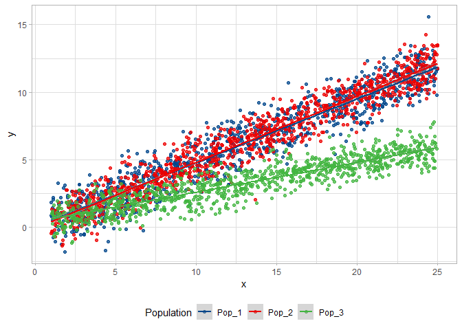

```r
Res_DF %>% ggplot(aes(x, y, color = Population)) +
  geom_point(alpha = 0.75) +
  geom_smooth(method = 'lm') +
  scale_color_lancet() +
  theme_light() +
  theme(legend.position = "bottom")
```

A estas alturas conviene repasar la fórmula de la regresión lineal:

$$y = intercept + x*slope$$

Por consiguiente, podemos entrenar un modelo de regresión lineal para cada población (con sus respectivas pendientes e intercepts) y tras ello obtener tres nuevas estimaciones de *y* (una por modelo) en base a los coeficientes. Tras esto basta con comparar si hay diferencias estadísticamente significativas entre las tres nuevas estimaciones de *y*.

Empezamos con la primera población:

```r
# Slope and intercept for population 1
Temp <- Res_DF %>% filter(Population == "Pop_1")
lm_1 <- lm(y ~ x, Temp)

lm_1_Inter <- lm_1$coefficients[1]
lm_1_Slope <- lm_1$coefficients[2]

lm_1_Inter; lm_1_Slope
```

```
## (Intercept)
##  0.04739327
```

```
##         x
## 0.4730589
```

Segunda y tercera poblaciones:

```r
# Slope and intercept for population 2
Temp <- Res_DF %>% filter(Population == "Pop_2")
lm_2 <- lm(y ~ x, Temp)

lm_2_Inter <- lm_2$coefficients[1]
lm_2_Slope <- lm_2$coefficients[2]

# Slope and intercept for population 3
Temp <- Res_DF %>% filter(Population == "Pop_3")
lm_3 <- lm(y ~ x, Temp)

lm_3_Inter <- lm_3$coefficients[1]
lm_3_Slope <- lm_3$coefficients[2]
```

Ahora que disponemos de los intercepts y pendientes de cada modelo podemos calcular las nuevas estimaciones de *y*:

```r
# New estimations of y
New_y <- Res_DF %>%
  transmute(
    y_1 = lm_1_Inter + (x * lm_1_Slope),
    y_2 = lm_2_Inter + (x * lm_2_Slope),
    y_3 = lm_3_Inter + (x * lm_3_Slope))

head(New_y)
```

| y_1 | y_2 | y_3 |
| --- | --- | --- |
| 1.668401 | 1.611435 | 1.163913 |
| 11.339573 | 11.585672 | 5.667322 |
| 6.292989 | 6.380944 | 3.317366 |
| 11.456759 | 11.706530 | 5.721890 |
| 7.867060 | 8.004342 | 4.050337 |
| 6.427852 | 6.520033 | 3.380165 |

Una vez obtenidos los nuevos datos podemos hacer un box y violín plot que nos permita ver la distribución de estimación de valores según las nuevas estimaciones de *y*.

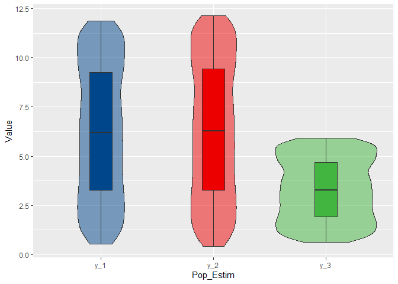

```r
New_y %>%
  pivot_longer(
    cols = c(y_1, y_2, y_3),
    names_to = "Pop_Estim",
    values_to = "Value"
  ) %>%
  ggplot(aes(Pop_Estim, Value, fill = Pop_Estim)) +
  geom_violin(alpha = 0.5) +
  geom_boxplot(width = 0.2) +
  scale_fill_lancet() +
  theme(legend.position = "none")
```

Rematamos el análisis con un ANOVA comparando las tres nuevas estimaciones de *y* (a estas alturas ya resulta evidente que las estimaciones de y realizadas a partir del modelo de regresión lineal de la población 3 van a ser diferentes de las otras dos poblaciones).

```r
# ANOVA on new estimations of y
y_anova <- New_y %>%
  pivot_longer(
    cols = c(y_1, y_2, y_3),
    names_to = "Pop_Estim",
    values_to = "Value"
  )

summary(aov(Value ~ Pop_Estim, data = y_anova))
```

```
##               Df Sum Sq Mean Sq F value Pr(>F)
## Pop_Estim      2  17896    8948    1050 <2e-16 ***
## Residuals   8997  76695       9
## ---
## Signif. codes:  0 '***' 0.001 '**' 0.01 '*' 0.05 '.' 0.1 ' ' 1
```

A esto añadimos un students-t test para determinar si las estimaciones de *y* usando las regresiones de las poblaciones 1 y 2 proporcionan valores que difieren significativamente. Confirmamos lo que ya habíamos intuido en el scatter plot y el violín-box plot: no hay diferencia estadísticamente significativa. Por consiguiente entrenar un modelo que incluya datos de las poblaciones 1 y 2 es correcto.

```r
# t-test of values from new estimations of y from pop 1 and 2
t.test(New_y$y_1, New_y$y_2)
```

```
##
##  Welch Two Sample t-test
##
## data:  New_y$y_1 and New_y$y_2
## t = -0.98247, df = 5992.3, p-value = 0.3259
## alternative hypothesis: true difference in means is not equal to 0
## 95 percent confidence interval:
##  -0.25846786  0.08588721
## sample estimates:
## mean of x mean of y
##  6.239861  6.326152
```

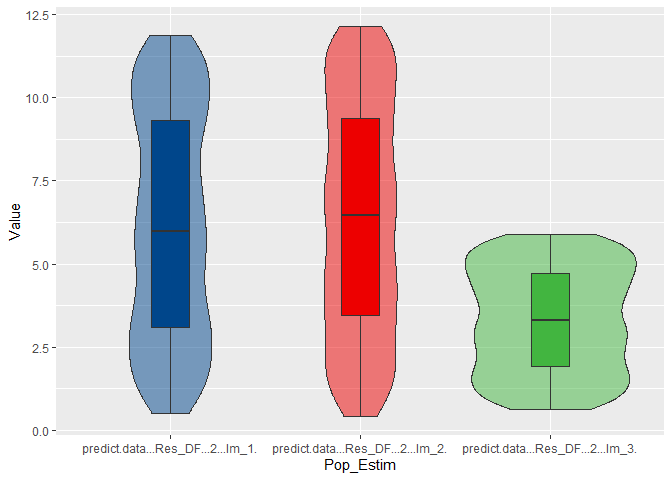

```r
# Generate predictions wwith models
Alt <- data.frame(
  predict(data = Res_DF[,2], lm_1),
  predict(data = Res_DF[,2], lm_2),
  predict(data = Res_DF[,2], lm_3))

# Plot violin and box plot
Alt %>% pivot_longer(
    cols = starts_with("p"),
    names_to = "Pop_Estim",
    values_to = "Value"
  ) %>%
  ggplot(aes(Pop_Estim, Value, fill = Pop_Estim)) +
  geom_violin(alpha = 0.5) +
  geom_boxplot(width = 0.2) +
  scale_fill_lancet() +
  theme(legend.position = "none")
```